# R Notebook

### Pŕe-processamento em R com a base de dados *bancoufba.csv*

### Agenda

- Introdução
- Limpesa
- Exploração
- Transformação
- Redução de Dimensionalidade

```r
# lendo a base de dados
banco = read.csv('../data/bancoufba.csv')
# listando o nome dos atributos
names(banco)
```

```
[1] "cpf"              "sexo"             "salario"          "estado"
[5] "poupanca"         "altura"           "peso"             "total.emprestimo"
[9] "financiamento"
```

```r
# visualizando alguns atributos
head(banco)
```

|  | cpf | sexo | salario | estado | poupanca | altura | peso | total.emprestimo | financiamento |
| --- | --- | --- | --- | --- | --- | --- | --- | --- | --- |
| 1 | 741132012 | M | 5124.00 | MA | -1000.00 | 1.93 | 85.62 | 0 | S |
| 2 | 246313940 | F | 4772.45 | SP | 15012.90 | 1.84 | 99.12 | NA | S |
| 3 | 431872706 | F | 5001.80 | BA | 0.00 | 1.66 | 104.39 | 0 | N |
| 4 | 127070574 | F | 5279.32 | DF | 0.00 | 1.73 | 72.57 | 0 | S |
| 5 | 620680271 | M | 5327.52 | RS | 8172.68 | 2.05 | 97.89 | 0 | S |
| 6 | 939260408 | M | 5229.73 | SE | 0.00 | 1.69 | 74.25 | 0 | S |

```r
# verificando os níveis de um determinado atributo
levels(banco$sexo)
```

```
[1] "F" "M"
```

```r
levels(banco$estado)
```

```
 [1] "AC" "AL" "AM" "AP" "BA" "CE" "DF" "ES" "GO" "MA" "MG" "MS" "MT" "PA" "PB" "PE"
[17] "PI" "PR" "RJ" "RN" "RO" "RR" "RS" "SC" "SE" "SP" "TO"
```

```r
# média -  no exemplo todos os pesos das instâncias
mean(banco$peso)
```

```
[1] 92.8259
```

```r
# mediana
median(banco$peso)
```

```
[1] 95.18
```

```r
# mínino e maximo
min(banco$peso)
```

```
[1] 55.55
```

```r
max(banco$peso)
```

```
[1] 129.89
```

```r
# Moda - o valor mais frequente nas minhas instâncias - rever isso.
sort(table(banco$estado), decreasing = T)[1]
```

```
AC
13
```

```r
# Resumo dos Dados no atributo Salário
summary(banco$salario)
```

```
   Min. 1st Qu.  Median    Mean 3rd Qu.    Max.    NA's
   4000    4581    5094    5799    5489   25720       5
```

```r
# Resumo dos dados em toda a base
summary(banco)
```

```
      cpf            sexo       salario          estado       poupanca
 Min.   : 19593780   F: 92   Min.   : 4000   AC     : 13   Min.   :-1000
 1st Qu.:301568359   M:118   1st Qu.: 4581   MS     : 13   1st Qu.:    0
 Median :571129336           Median : 5094   SC     : 12   Median :    0
 Mean   :531321108           Mean   : 5799   MA     : 11   Mean   : 3908
 3rd Qu.:766159015           3rd Qu.: 5489   MG     : 11   3rd Qu.: 7306
 Max.   :999966843           Max.   :25716   SP     : 11   Max.   :19529
                             NA's   :5       (Other):139   NA's   :5
     altura            peso        total.emprestimo financiamento
 Min.   : 1.400   Min.   : 55.55   Min.   :  0.0    N   :121
 1st Qu.: 1.620   1st Qu.: 77.97   1st Qu.:  0.0    S   : 84
 Median : 1.785   Median : 95.18   Median :  0.0    NA's:  5
 Mean   : 2.240   Mean   : 92.83   Mean   :154.0
 3rd Qu.: 1.978   3rd Qu.:106.23   3rd Qu.:443.3
 Max.   :11.980   Max.   :129.89   Max.   :600.0
                                   NA's   :5
```

```r
# calculando a variãnça - dado peso é atributo Racional
var(banco$peso)
```

```
[1] 393.9874
```

```r
# calculando o desvio padrão - ate agora todas essas métricas estatísticas o R ja tem as funções
sd(banco$peso)
```

```
[1] 19.84912
```

# Visualização

## Boxplot

Para o pré processamento dos dados podemos visualiza-los os dados para compreender uma maior abstração e fazer melhores induções sobre os mesmo para então conferir se uma determinada hipótesi aplica aos dados. Nessa etapa de pré-processamento podemos utilizar o **Boxplot** para avaliar a distribuição empírica dos dados. O **Boxplot** é formado pelo primeiro, terceiro quartil e pela mediana.

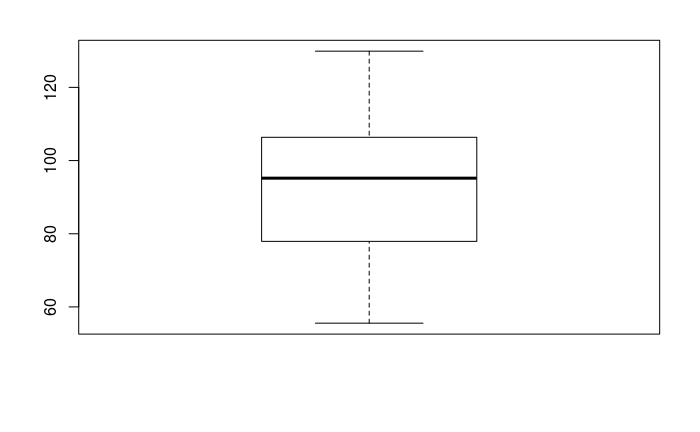

```r
# boxplot so aceita valores numericos ? por usar quartis e medianas, pode ser que sim
boxplot(banco$peso)
```

As hastes inferiores e superiores se estendem, respectivamente, do quartil inferior até o menor valor não inferior ao limite inferior e do quartil superior até o maior valor não superior ao limite superior. Pontos foras desses limites são considerados valores discrepantes (**outliers**). Como exemplos temos:

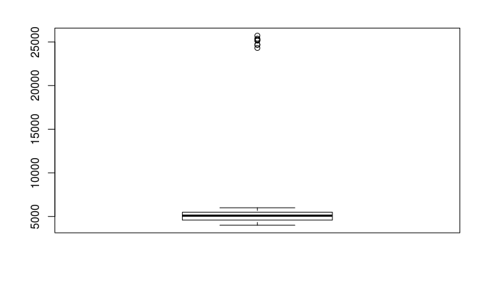

```r
boxplot(banco$salario)
```

## Histograma

Distribuição de frequências é um agrupamento de dados em classes contabilizando o número de ocorrências em cada clases. O número de ocorrências de uma determinada classe recebe o nome de frequência absoluta. O *Objetivo* é apresentar os dados de uma maneira mais concisa e que nos permita extrair informações sobre seu comportamento.

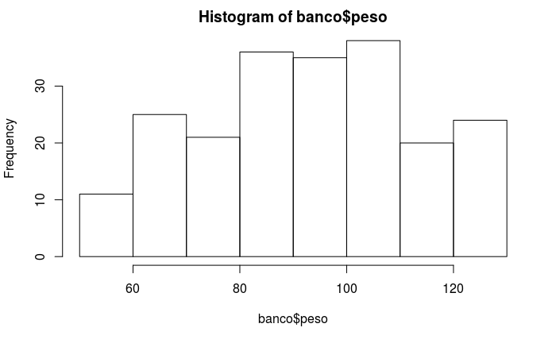

```r
hist(banco$peso)
```

## Transformando dados e Reduzindo a dimensionalidade

### Transformação

Várias técnicas de AM são limitadas ao tipo dos atributos: apenas valores numéricos ou apenas valores simbólicos. RNA e SVM são exemplos de técnicas que lidam apenas com dados numéricos. Pode-se fazer a conversão de valores como solução.

##### Conversão Simbólico-Numérico

- Atributo nominal com dois valores que representam presença ou ausência de uma característica. Pode-se substituir por um dígito binário.
- Atributo nominal com dois valores que representam relação de ordem. Pode-se substituir por um dígito binário

```r
# como exemplo o atributo sexo, que é nominal(simbólico), e queremos trabalhar com dados numéricos.
levels(banco$sexo)
```

```
[1] "F" "M"
```

```r
# procura as instância onde encontrar o atributo 'F'
which(banco$sexo=="F")
```

```
 [1]   2   3   4   7   8  10  12  17  18  19  20  22  23  24  26  28  34  35  38  43
[21]  45  48  51  53  58  62  66  68  69  72  73  74  76  77  81  82  84  90  91  93
[41]  94  96 100 104 109 114 116 118 119 120 121 122 123 124 125 129 132 133 135 136
[61] 137 138 142 148 149 150 151 152 153 155 157 159 160 161 163 164 168 171 172 173
[81] 175 176 180 187 188 192 193 196 202 203 204 210
```

```r
# vetor que armazena os atributos do sexo
temp<-as.vector(banco$sexo)
# faz a tranformação de valores - 0 para M, 1 para F
temp[which(temp=="M")] = "0"
temp[which(temp=="F")] = "1"
#atribui na minha base os atributos tranformados como inteiros
banco$sexo <- as.integer(temp)
# lista os novos valores dos atributos
head(banco$sexo)
```

```
[1] 0 1 1 1 0 0
```

### Conversão Numérico-Simbólico

- Uma parcela dos algortimos de classificação e de associaçãi foram desenvolvidos para trabalhar com valores quantitativos. Atributo quantitativo do tipo discreto ou binário, com apenas dois valores.
  - Conversão Trivial: associar um nomea cada valor.
- Atributos quantitativos numéricos
  - Discretização : transformação de valores numéricos em intervalos.
  - Existem vários métodos de discretização, o mais simples é a média.

### Tranformação dos atributos numéricos

- Transformar um valor numérico em outro valor numérico.
- Isso ocorre quando os limites inferior e superior de valores dos atributos são muito diferentes.
- Ou quando vários atributos estão em escalas diferentes.
- A transformação é necessária para evitar que um atributo predomine sobre outro. Pode se usar por exemplo a *normalização* dos dados.

### DATASETS

- [Machine Learning Repository](https://archive.ics.uci.edu/ml/datasets.html)
- [UCI KDD Archive](http://kdd.ics.uci.edu/summary.data.application.html)
- [Delve](http://www.cs.utoronto.ca/~delve/)